# Basic Plotting and Statistics in R

# Welcome to Data Visualization and Statistics in R!

In this 2-hour session, we’ll learn how to: - Create beautiful and informative plots using ggplot2 - Understand basic statistical concepts - Perform data analysis using R - Make data-driven decisions

## Required Packages

We’ll be using these R packages:

```r
# Load the tidyverse package which includes:
# - ggplot2 for data visualization
# - dplyr for data manipulation
# - tidyr for data tidying
# - readr for data import
library(tidyverse)

# Load the datasets package which contains example datasets
# like mtcars, iris, etc.
library(datasets)
```

## Part 1: Getting Started with R for Statistics

Let’s begin by exploring some built-in datasets in R. We’ll use the famous `mtcars` dataset:

```r
# Load the mtcars dataset (contains information about various car models)
data("mtcars")

# Show first few rows to understand data structure
head(mtcars)
```

```
##                    mpg cyl disp  hp drat    wt  qsec vs am gear carb
## Mazda RX4         21.0   6  160 110 3.90 2.620 16.46  0  1    4    4
## Mazda RX4 Wag     21.0   6  160 110 3.90 2.875 17.02  0  1    4    4
## Datsun 710        22.8   4  108  93 3.85 2.320 18.61  1  1    4    1
## Hornet 4 Drive    21.4   6  258 110 3.08 3.215 19.44  1  0    3    1
## Hornet Sportabout 18.7   8  360 175 3.15 3.440 17.02  0  0    3    2
## Valiant           18.1   6  225 105 2.76 3.460 20.22  1  0    3    1
```

```r
# Calculate key statistics about miles per gallon (mpg):
# - mean: average fuel efficiency
# - median: middle value (robust to outliers)
# - sd: spread of the data (how much variation exists)
mtcars %>%
  summarise(across(mpg,
                  list(mean = mean,
                       median = median,
                       sd = sd),
                  .names = "{.fn}_mpg"))
```

```
##   mean_mpg median_mpg   sd_mpg
## 1 20.09062       19.2 6.026948
```

## Part 2: Creating Beautiful Visualizations

### Basic Histogram

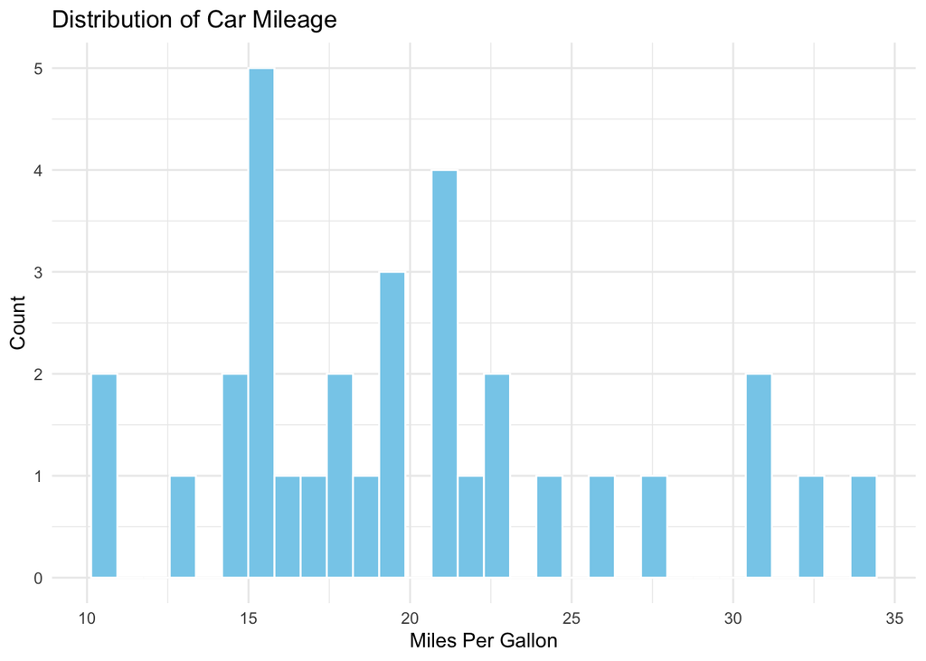

```r
# Create a basic histogram to visualize MPG distribution
ggplot(mtcars, aes(x = mpg)) +               # Set up plot with MPG on x-axis
  geom_histogram(
    fill = "skyblue",                        # Color the bars light blue
    color = "white",                         # White borders make bars distinct
    bins = 30                                # Number of bars (more = more detail)
  ) +
  labs(
    title = "Distribution of Car Mileage",   # Main title explains the plot
    x = "Miles Per Gallon",                  # X-axis shows the unit
    y = "Count"                              # Y-axis shows frequency
  ) +
  theme_minimal()                            # Clean, modern look
```

### Adding Density Curves

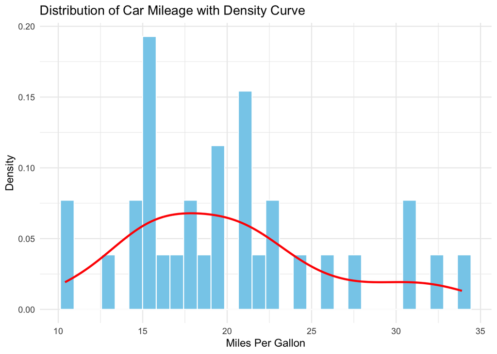

```r
# Create a histogram with density curve overlay
ggplot(mtcars, aes(x = mpg)) +
  # Add histogram scaled to density
  geom_histogram(
    aes(y = ..density..),  # Scale y-axis to density instead of count
    fill = "skyblue",
    color = "white"
  ) +
  # Add a smoothed density curve
  geom_density(
    color = "red",        # Color of density line
    linewidth = 1         # Thickness of density line
  ) +
  # Add descriptive labels
  labs(
    title = "Distribution of Car Mileage with Density Curve",
    x = "Miles Per Gallon",
    y = "Density"
  ) +
  theme_minimal()
```

## Part 3: Understanding Data Distributions

### What is a Distribution?

A distribution shows us the “shape” of our data. Think of it as a way to see: - How often different values occur - What values are typical or unusual - How spread out the data is

Common examples in research: - Heights in a population - Test scores in a class - Gene expression levels - Treatment responses

### The Normal Distribution

The “normal” or “bell-shaped” distribution is the most common in nature. Key features: 1. It’s symmetric around the mean 2. The mean, median, and mode are all equal 3. About 68% of data falls within 1 standard deviation of the mean 4. About 95% of data falls within 2 standard deviations 5. About 99.7% of data falls within 3 standard deviations

Let’s visualize this with our data:

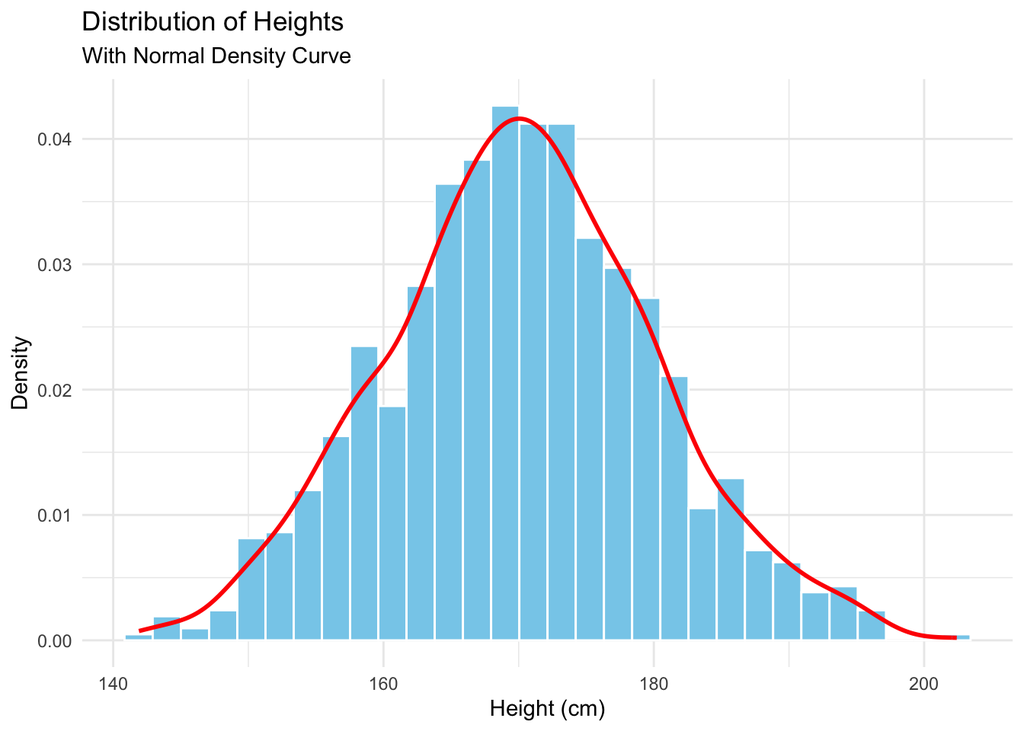

```r
# Generate synthetic height data for demonstration
set.seed(123)                                # Make results reproducible
heights <- rnorm(1000,                       # Generate 1000 random heights
                mean = 170,                  # Average height in cm
                sd = 10)                     # Standard deviation in cm

# Create visualization of height distribution
ggplot(data.frame(height = heights),         # Convert heights to data frame
       aes(x = height)) +                    # Map height to x-axis
  geom_histogram(
    aes(y = ..density..),                    # Scale to density for comparison
    fill = "skyblue",
    color = "white",
    bins = 30
  ) +
  geom_density(color = "red",                # Add smooth density curve
               linewidth = 1) +
  labs(
    title = "Distribution of Heights",
    subtitle = "With Normal Density Curve",
    x = "Height (cm)",
    y = "Density"
  ) +
  theme_minimal()
```

```r
# Create summary statistics table
tibble(
  # Define statistics to show
  Statistic = c("Mean", "Median", "SD",
                "Within 1 SD", "Within 2 SD", "Within 3 SD"),
  # Calculate values
  Value = c(
    mean(heights),                           # Average height
    median(heights),                         # Middle height
    sd(heights),                            # Spread of heights
    # Calculate % within each SD range
    mean(abs(scale(heights)) <= 1) * 100,   # Within 1 SD
    mean(abs(scale(heights)) <= 2) * 100,   # Within 2 SD
    mean(abs(scale(heights)) <= 3) * 100    # Within 3 SD
  ),
  # Add units for clarity
  Unit = c("cm", "cm", "cm", "%", "%", "%")
) %>%
  mutate(Value = round(Value, 1)) %>%        # Round all values to 1 decimal
  knitr::kable(caption = "Summary Statistics for Height Distribution")
```

Summary Statistics for Height Distribution

| Statistic | Value | Unit |
| --- | --- | --- |
| Mean | 170.2 | cm |
| Median | 170.1 | cm |
| SD | 9.9 | cm |
| Within 1 SD | 67.4 | % |
| Within 2 SD | 95.2 | % |
| Within 3 SD | 99.9 | % |

### Understanding Different Types of Distributions

Let’s explore different types of distributions we might encounter:

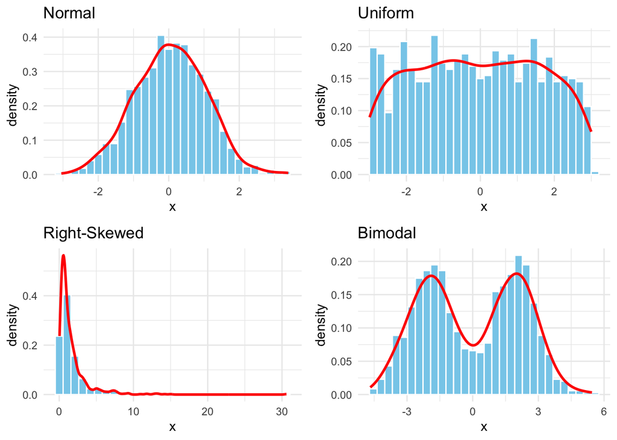

```r
# Generate different types of distributions (1000 points each)
n <- 1000
distributions <- tibble(
  normal = rnorm(n),                         # Symmetric, bell-shaped
  uniform = runif(n, -3, 3),                # Equal probability across range
  right_skewed = exp(rnorm(n)),             # Tail extends to the right
  bimodal = c(rnorm(n/2, -2), rnorm(n/2, 2)) # Two peaks
)

# Function to create standardized distribution plots
plot_distribution <- function(data, title) {
  ggplot(data.frame(x = data), aes(x = x)) +
    # Show distribution as both histogram and density
    geom_histogram(aes(y = ..density..),     # Scale to density
                  fill = "skyblue",
                  color = "white",
                  bins = 30) +
    geom_density(color = "red",              # Add smooth curve
                 linewidth = 1) +
    labs(title = title) +
    theme_minimal()
}

# Create and arrange all plots in a grid
library(gridExtra)
grid.arrange(
  # Create each type of distribution plot
  plot_distribution(distributions$normal, "Normal"),
  plot_distribution(distributions$uniform, "Uniform"),
  plot_distribution(distributions$right_skewed, "Right-Skewed"),
  plot_distribution(distributions$bimodal, "Bimodal"),
  ncol = 2                                   # Arrange in 2 columns
)
```

## Part 4: Statistical Testing

### The t-test: A Detective’s Tool

Think of a t-test like being a detective. You start with: - A question: “Are these groups different?” - A null hypothesis (H₀): “There is no real difference” - An alternative hypothesis (H₁): “There is a real difference”

Let’s walk through a complete example:

```r
# Create two groups to compare
set.seed(123)  # For reproducibility
group1 <- rnorm(30, mean = 100, sd = 15)  # Control group
group2 <- rnorm(30, mean = 115, sd = 15)  # Treatment group

# Perform t-test
t_result <- t.test(group1, group2)

# Create summary table of results
data.frame(
  Measure = c("Mean difference", "t-statistic", "p-value", "95% CI"),
  Value = c(
    round(mean(group2) - mean(group1), 2),
    round(t_result$statistic, 2),
    format.pval(t_result$p.value, digits = 3),
    paste(round(t_result$conf.int, 2), collapse = " to ")
  )
) %>%
  knitr::kable(caption = "T-test Results")
```

T-test Results

| Measure | Value |
| --- | --- |
| Mean difference | 18.38 |
| t-statistic | -5.21 |
| p-value | 2.75e-06 |
| 95% CI | -25.45 to -11.32 |

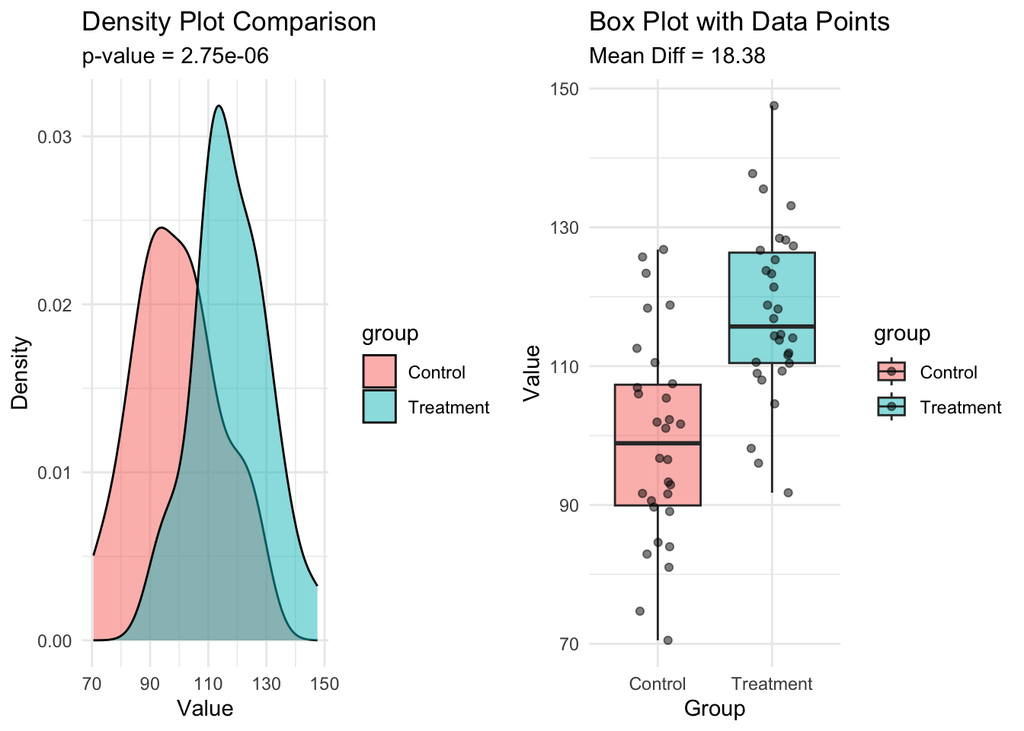

```r
# Create data frame for plotting
test_data <- data.frame(
  value = c(group1, group2),
  group = rep(c("Control", "Treatment"), each = 30)
)

# Create comprehensive visualization
p1 <- ggplot(test_data, aes(x = value, fill = group)) +
  geom_density(alpha = 0.5) +
  labs(
    title = "Density Plot Comparison",
    subtitle = paste("p-value =", format.pval(t_result$p.value, digits = 3)),
    x = "Value",
    y = "Density"
  ) +
  theme_minimal()

p2 <- ggplot(test_data, aes(x = group, y = value, fill = group)) +
  geom_boxplot(alpha = 0.5) +
  geom_jitter(width = 0.2, alpha = 0.5) +
  labs(
    title = "Box Plot with Data Points",
    subtitle = paste(
      "Mean Diff =", round(mean(group2) - mean(group1), 2)
    ),
    x = "Group",
    y = "Value"
  ) +
  theme_minimal()

# Display plots side by side
grid.arrange(p1, p2, ncol = 2)
```

### Checking t-test Assumptions

Let’s verify if our data meets the t-test assumptions:

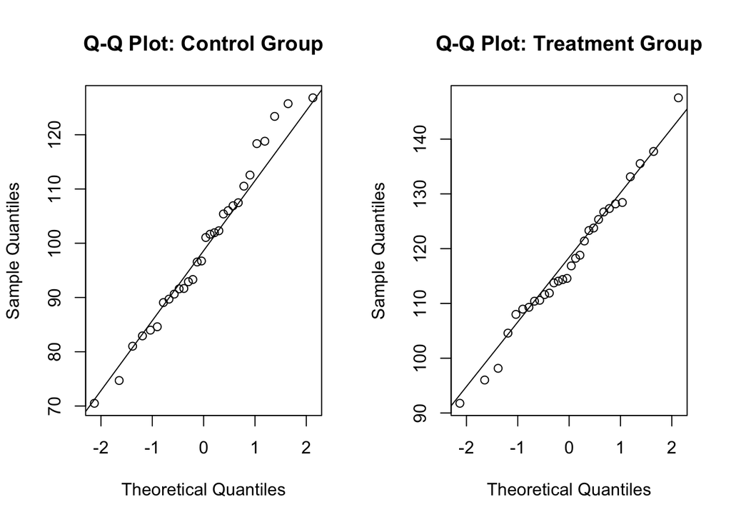

```r
# 1. Check normality with Q-Q plots
par(mfrow = c(1, 2))
qqnorm(group1, main = "Q-Q Plot: Control Group")
qqline(group1)
qqnorm(group2, main = "Q-Q Plot: Treatment Group")
qqline(group2)
```

```r
par(mfrow = c(1, 1))

# 2. Check equal variances and create summary table
var_test <- var.test(group1, group2)
data.frame(
  Test = c("F statistic", "p-value"),
  Value = c(
    round(var_test$statistic, 3),
    format.pval(var_test$p.value, digits = 3)
  )
) %>%
  knitr::kable(caption = "Variance Test Results")
```

Variance Test Results

|  | Test | Value |
| --- | --- | --- |
| F | F statistic | 1.38 |
|  | p-value | 0.391 |

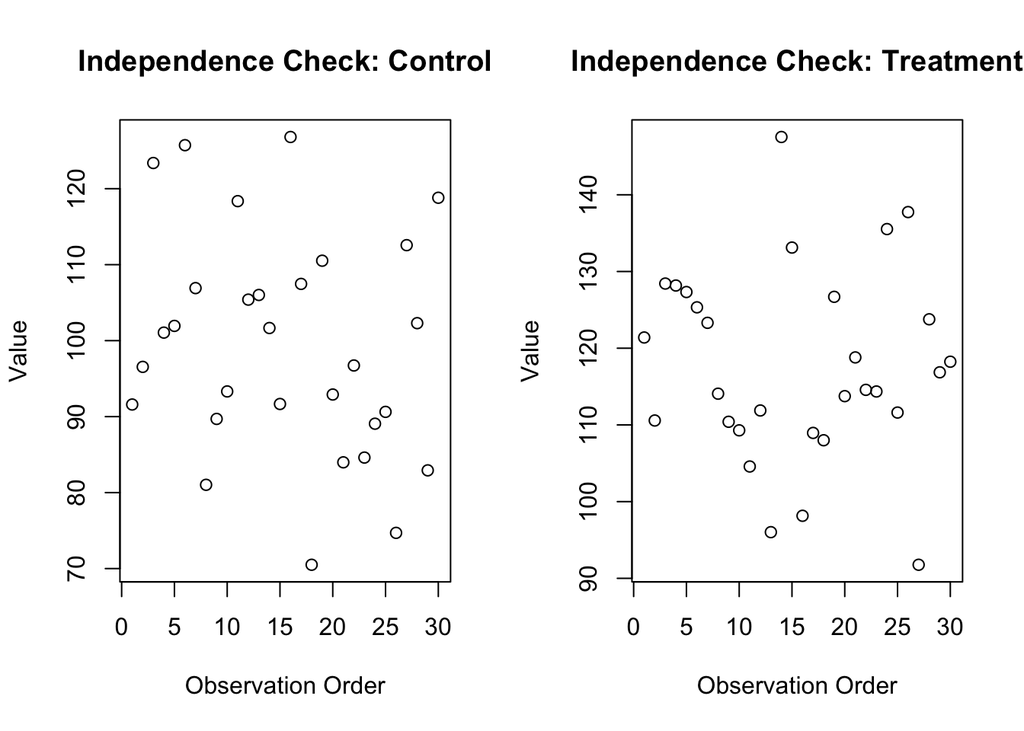

```r
# 3. Visual check for independence
par(mfrow = c(1, 2))
plot(seq_along(group1), group1,
     main = "Independence Check: Control",
     xlab = "Observation Order",
     ylab = "Value")
plot(seq_along(group2), group2,
     main = "Independence Check: Treatment",
     xlab = "Observation Order",
     ylab = "Value")
```

```r
par(mfrow = c(1, 1))
```

## Part 5: Exploring Relationships

### Scatter Plots and Regression Lines

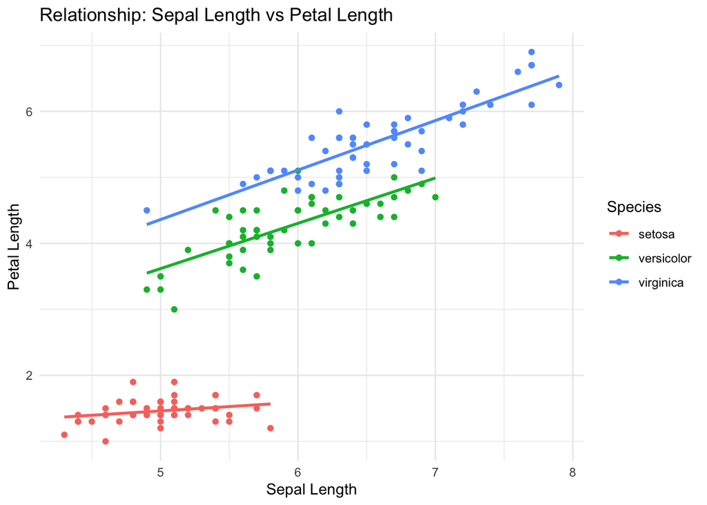

```r
# Create scatter plot showing relationship between sepal and petal length
ggplot(iris, aes(x = Sepal.Length, y = Petal.Length, color = Species)) +
  # Add points for each observation
  geom_point() +
  # Add regression lines for each species
  geom_smooth(
    method = "lm",    # Use linear regression
    se = FALSE        # Don't show confidence interval
  ) +
  # Add descriptive labels
  labs(
    title = "Relationship: Sepal Length vs Petal Length",
    x = "Sepal Length",
    y = "Petal Length"
  ) +
  theme_minimal()
```

## Practice Exercises

Here are some exercises to try on your own:

### Exercise 1: Basic Data Exploration

```r
# Your code here:
# 1. Calculate summary statistics for mtcars
# 2. Create a visualization of car weights
```

### Exercise 2: Group Comparisons

```r
# Your code here:
# 1. Compare mileage by number of cylinders
# 2. Create visualizations
# 3. Perform statistical test
```

### Exercise 3: Relationship Analysis

```r
# Your code here:
# 1. Investigate weight vs mileage
# 2. Create scatter plot with regression
# 3. Calculate correlation
```

## Solutions to Exercises

### Solution 1

```r
# Calculate summary statistics for car weights
mtcars %>%
  summarise(
    mean_wt = mean(wt),    # Average weight
    sd_wt = sd(wt),        # Standard deviation of weight
    min_wt = min(wt),      # Minimum weight
    max_wt = max(wt)       # Maximum weight
  )
```

```
##   mean_wt     sd_wt min_wt max_wt
## 1 3.21725 0.9784574  1.513  5.424
```

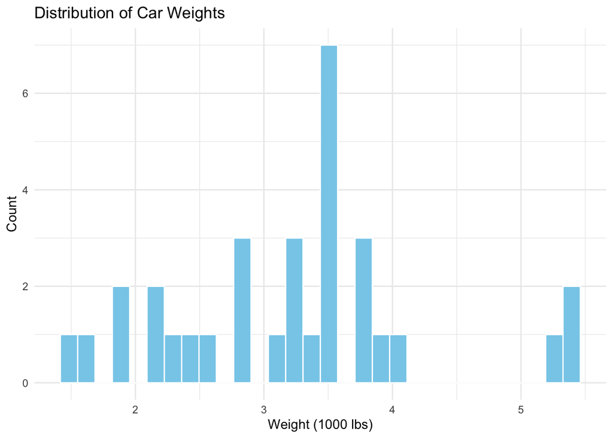

```r
# Create histogram of car weights
ggplot(mtcars, aes(x = wt)) +
  # Add histogram with custom appearance
  geom_histogram(
    fill = "skyblue",
    color = "white"
  ) +
  # Add descriptive labels
  labs(
    title = "Distribution of Car Weights",
    x = "Weight (1000 lbs)",
    y = "Count"
  ) +
  theme_minimal()
```

### Solution 2

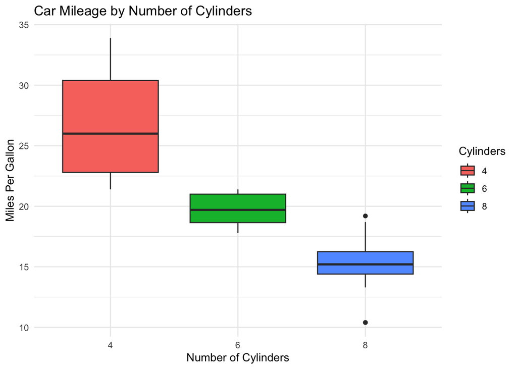

```r
# Create boxplot comparing mileage across different cylinder counts
ggplot(mtcars, aes(x = factor(cyl), y = mpg, fill = factor(cyl))) +
  # Add boxplot for each cylinder group
  geom_boxplot() +
  # Add descriptive labels
  labs(
    title = "Car Mileage by Number of Cylinders",
    x = "Number of Cylinders",
    y = "Miles Per Gallon",
    fill = "Cylinders"
  ) +
  theme_minimal()
```

```r
# Perform one-way ANOVA to test for differences between cylinder groups
aov_result <- aov(mpg ~ factor(cyl), data = mtcars)
# Display ANOVA results
summary(aov_result)
```

```
##             Df Sum Sq Mean Sq F value   Pr(>F)
## factor(cyl)  2  824.8   412.4    39.7 4.98e-09 ***
## Residuals   29  301.3    10.4
## ---
## Signif. codes:  0 '***' 0.001 '**' 0.01 '*' 0.05 '.' 0.1 ' ' 1
```

### Solution 3

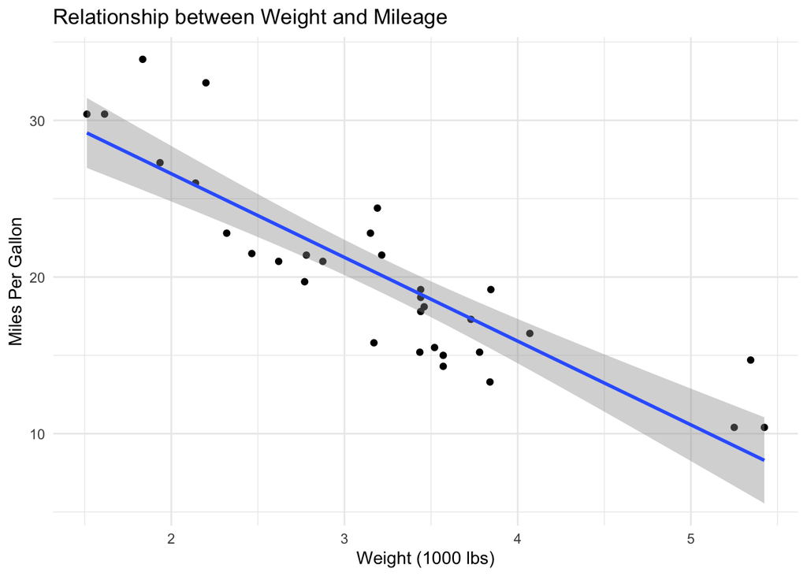

```r
# Create scatter plot showing relationship between weight and mileage
ggplot(mtcars, aes(x = wt, y = mpg)) +
  # Add points for each car
  geom_point() +
  # Add regression line with confidence interval
  geom_smooth(
    method = "lm",    # Use linear regression
    se = TRUE         # Show confidence interval
  ) +
  # Add descriptive labels
  labs(
    title = "Relationship between Weight and Mileage",
    x = "Weight (1000 lbs)",
    y = "Miles Per Gallon"
  ) +
  theme_minimal()
```

```r
# Calculate correlation between weight and mileage
cor.test(mtcars$wt, mtcars$mpg)
```

```
##
##  Pearson's product-moment correlation
##
## data:  mtcars$wt and mtcars$mpg
## t = -9.559, df = 30, p-value = 1.294e-10
## alternative hypothesis: true correlation is not equal to 0
## 95 percent confidence interval:
##  -0.9338264 -0.7440872
## sample estimates:
##        cor
## -0.8676594
```